# Assignment 1

Ulrike Maria Dauter

Task 1

What is the medically relevant insight from the article? Mobile element variants (MEVs) significantly contribute to diversification of the human genome, gene regulation and disease risk. Specific MEVs such as Alu, LINE-1 (L1) and SINE-VNTR-Alu (SVA) show population-specific distributions and take part in regulating tissue-specific gene expression. MEVs can be more strongly associated with gene expression changes than single-nucleotide variants, which suggests that it is possible for them to drive phenotypic traits, including disease susceptibilities. One L1 insertion in this dtudy was linked to an increased risk for keloid formation and fasciitis

Which genomics technology/ technologies were used? Short-read whole-genome sequencing (WGS) mobile element genotype analysis environment (MEGAnE) (bioinformatic tool enabling discovery and genotyping of ME insertions and absences)

Three questions/ hypothesis to extend the analysis presented in the paper How do MEVs impact polygenic disease risks in different populations? What roles do MEVs play in epigenetic regulation snd chromativ state remodeling? Can MEVs be utilized as biomarkers for predicitng susceptibility to specific cimplex traits or diseases?

Task 4

Load the CO2 dataset into R and display the content of it with the help() function

```r
# Loading the CO2 dataset
data(CO2)
# Accessing description of the CO2 dataset using the help function
help(CO2)
```

Creating subsets of the data and calculating the average and median

```r
# Creating subsets of the dataset
Quebec <- subset(CO2, CO2$Type=="Quebec")
Mississippi <- subset(CO2, CO2$Type=="Mississippi")

# Calculating the average and median of the subdatasets
average_Quebec <- mean(Quebec$uptake)
average_Quebec
```

```
## [1] 33.54286
```

```r
average_Mississippi <- mean(Mississippi$uptake)
average_Mississippi
```

```
## [1] 20.88333
```

```r
median_Quebec <- median(Quebec$uptake)
median_Quebec
```

```
## [1] 37.15
```

```r
median_Mississippi <- median(Mississippi$uptake)
median_Mississippi
```

```
## [1] 19.3
```

Load and display “airway” data from bioconductor and counting the expressed genes per sample as well as how many genes were not expressed in general

```r
# Load and display airway data from Bioconductor
library(airway)
library(dbplyr)  # used for data manipulation

# useful when handling complex datasets in a more organized way
library(SummarizedExperiment)

data("airway")
airway_se <- airway  # stored as a SummarizedExperiment object

# Counting the number of expressed genes (count greater than 0)
# Extracting the counts matrix
counts_matrix <- assay(airway_se)

# Counting the number of genes that are expressed (count > 0) for each sample
expressed_genes_per_sample <- apply(counts_matrix, 2, function(x) sum(x > 0))
# The function apply (...,2,...) applies to each column of the count matrix,
# sum (x < 0) counts how many genes in one column (one sample)
# have an expression above 0
expressed_genes_per_sample
```

```
## SRR1039508 SRR1039509 SRR1039512 SRR1039513 SRR1039516 SRR1039517 SRR1039520
##      24633      24527      25699      23124      25508      25998      24662
## SRR1039521
##      23991
```

```r
# Counting the number of genes that are not expressed (count == 0)
genes_not_expressed <- sum(rowSums(counts_matrix) == 0)
# Counts how many genes are not expressed in any of the samples
# (not column (sample) specific)
genes_not_expressed
```

```
## [1] 30208
```

Expressed genes per sample: SRR1039508 SRR1039509 SRR1039512 SRR1039513 SRR1039516 SRR1039517 SRR1039520 SRR1039521 24633 24527 25699 23124 25508 25998 24662 23991

Number of genes that are not expressed: 30208

Task 5

Function to calculate the ratio of the mean and the median of a dataset.

```r
# Function to calculate the ratio of the mean and the median
mean_median_ratio <- function(x) {
  # Checking that input is numeric
  if (!is.numeric(x)) {
    stop("Input vector must be numeric.")
  }

  # Calculating the mean value
  mean_value <- mean(x, na.rm = TRUE)

  # Calculating the median
  median_value <- median(x, na.rm = TRUE)

  # Calculating the ratio of the mean to the median
  ratio <- mean_value/median_value

  # Return the ratio
  return(ratio)
}
```

Function to calculate the mean excluding the highest and the lowest value

```r
# Function to ignore lowest and highest value and calculates the mean
mean_without_extremes <- function(x) {
  # Checking that input is numeric
  if(!is.numeric(x)) {
    stop("Input vector must be numeric.")
  }

  # Input needs to have more than 2 values, otherwise it would return empty
  if (length(x) <= 2) {
    stop("Input vector must contain more than two elements.")
  }

  # Removing smallest and highest values
  x_filtered <- x[x != min(x) & x != max(x)]

  # Calculating the mean of the remaining values
  mean_value <- mean(x_filtered, na.rm = TRUE)

  # Return the mean
  retun(mean_value)
}
```

If the highest or lowest value is present more then once in a dataset this is a function which will only take out the value once

```r
# Alternative function if highest or lowest values occurs more then once.
# This will only remove the value once (the function above will remove all
# occurrences of the minimum
# and maximum values)
mean_without_extremes_single <- function(x) {
  # Checking that input is numeric
  if(!is.numeric(x)) {
    stop("Input vector must be numeric.")
  }

  # Input needs to have more than 2 values, otherwise it would return empty
  if (length(x) <= 2) {
    stop("Input vector must contain more than two elements.")
  }

  # Remove only one instance of the smallest and highest value
  x_filtered_single <- x[-which.min(x)]
  x_filtered_single <- x_filtered_single[-which.max(x_filtered_single)]

  # Calculating the mean of the remaining values
  mean_value_single <- mean(x_filtered_single, na.rm = TRUE)

  # Return the mean
  return(mean_value_single)
}
```

Piping chains commands/functions, passes output as input, reducing intermediate variables. It improves readability and organizes code linearly. However, for complex transformations or multiple inputs/outputs, avoiding pipes can make code easier to follow.

The apply family (apply, lapply, sapply, tapply, etc) simplifies repetitive tasks by applying functions to elements of data structures like lists, matrices, or vectors. It reduces code complexity and avoids loops, making operations faster and code easier to read. Useful for data manipulation.

Task 6

Comparing the body heights distribution for the two species of the magic guys dataset

```r
#Loading the required packages and the dataset
library(ggplot2)
library(readr)

magic_guys <- read_csv("magic_guys.csv")
```

Histograms for length of the two species

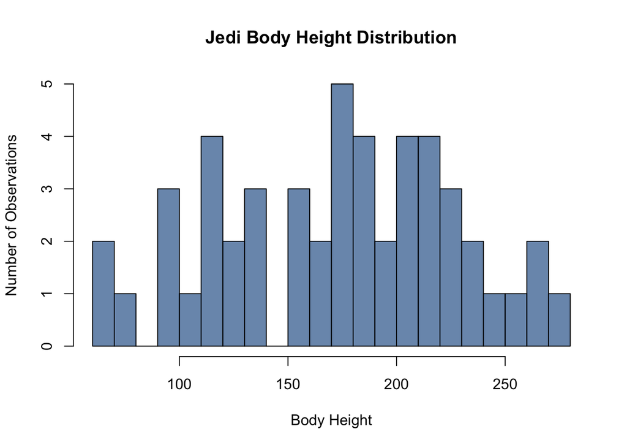

```r
jedi <- magic_guys$length[magic_guys$species == "jedi"]
sith <- magic_guys$length[magic_guys$species == "sith"]

# Histogram for jedi
hist(jedi, breaks = 20, col = rgb(0.2, 0.4, 0.6, 0.7),
     main = "Jedi Body Height Distribution",
     xlab = "Body Height",
     ylab = "Number of Observations")
```

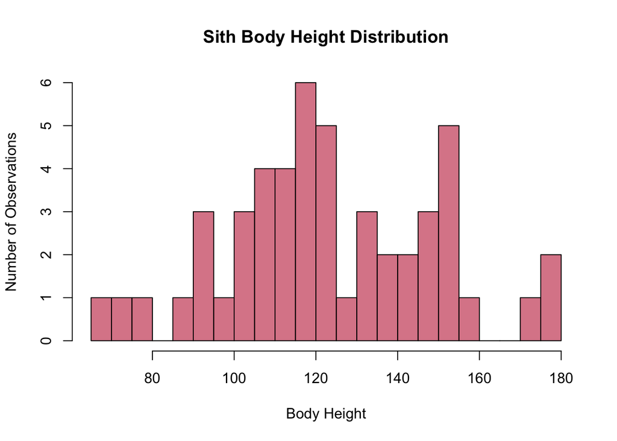

```r
# Histogram for sith
hist(sith, breaks = 20, col = rgb(0.8, 0.3, 0.4, 0.7),
     main = "Sith Body Height Distribution",
     xlab = "Body Height",
     ylab = "Number of Observations")
```

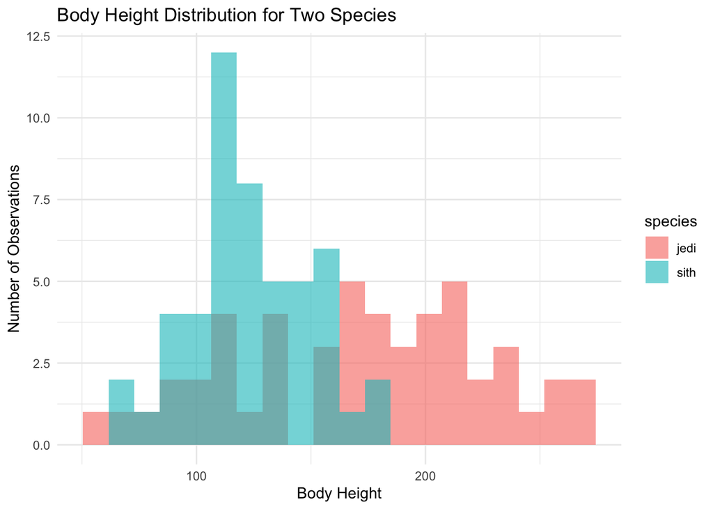

```r
# ggplot histogram
ggplot(magic_guys, aes(x = length, fill = species)) +
  geom_histogram(position = "identity", alpha = 0.6, bins = 20) +
  labs(title = "Body Height Distribution for Two Species",
       x = "Body Height",
       y = "Number of Observations") +
  theme_minimal()
```

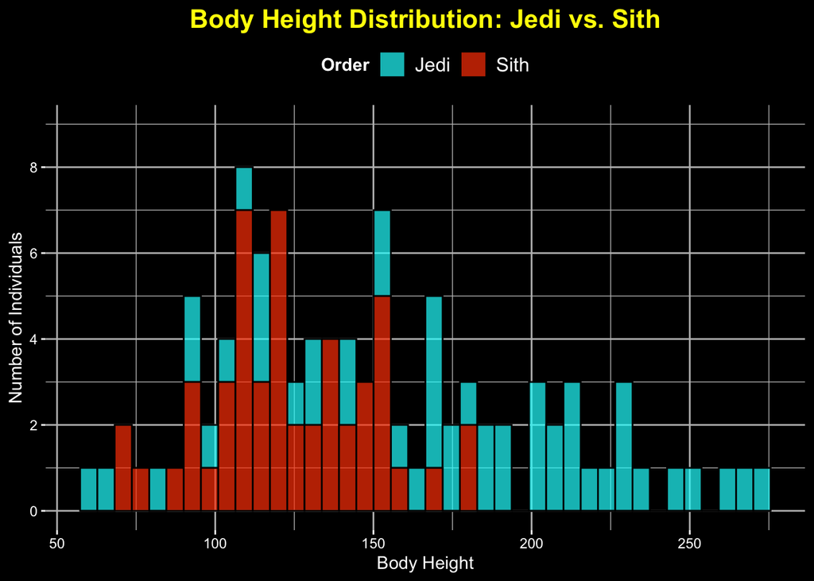

```r
## optimize ggplot (e.g. different breaks, stacked bars, etc.)
ggplot(magic_guys, aes(x = length, fill = species)) +

  geom_histogram(position = "stack", alpha = 0.7, bins = 40,
                 aes(y = after_stat(count)), color = "black", width = 0.2) +

  # Labels
  labs(
    title = "Body Height Distribution: Jedi vs. Sith",
    x = "Body Height",
    y = "Number of Individuals",  # Change y-axis label
    fill = "Order"  # Rename legend title
  ) +

  # Star Wars themed neon colors for Jedi (neon blue) and Sith (neon red)
  scale_fill_manual(
    values = c(
      "jedi" = "#00FFFF",  # Neon blue for Jedi
      "sith" = "#FF4500"   # Neon red for Sith
    ),
    labels = c(
      "jedi" = "Jedi",
      "sith" = "Sith"
    )
  ) +

  # Customize the y-axis to display even numbers, from 0 to 8
  scale_y_continuous(limits = c(0, 9), breaks = seq(0, 10, by = 2)) +

  # Star Wars themed plot design
  theme_minimal() +
  theme(
    legend.position = "top",  # Place legend on top
    legend.title = element_text(face = "bold", color = "white"),
    # Bold white legend title
    legend.text = element_text(size = 12, color = "white"),
    # White legend text
    plot.title = element_text(size = 16, face = "bold", hjust = 0.5, color = "yellow"),
    # Yellow Star Wars title
    plot.background = element_rect(fill = "black"),
    # Black background for Star Wars theme
    panel.background = element_rect(fill = "black"),
    axis.text = element_text(color = "white"),
    axis.title = element_text(color = "white"),
    axis.ticks = element_line(color = "white"),
    panel.grid = element_line(color = "gray")
  )
```

Boxplot to display length of the two species

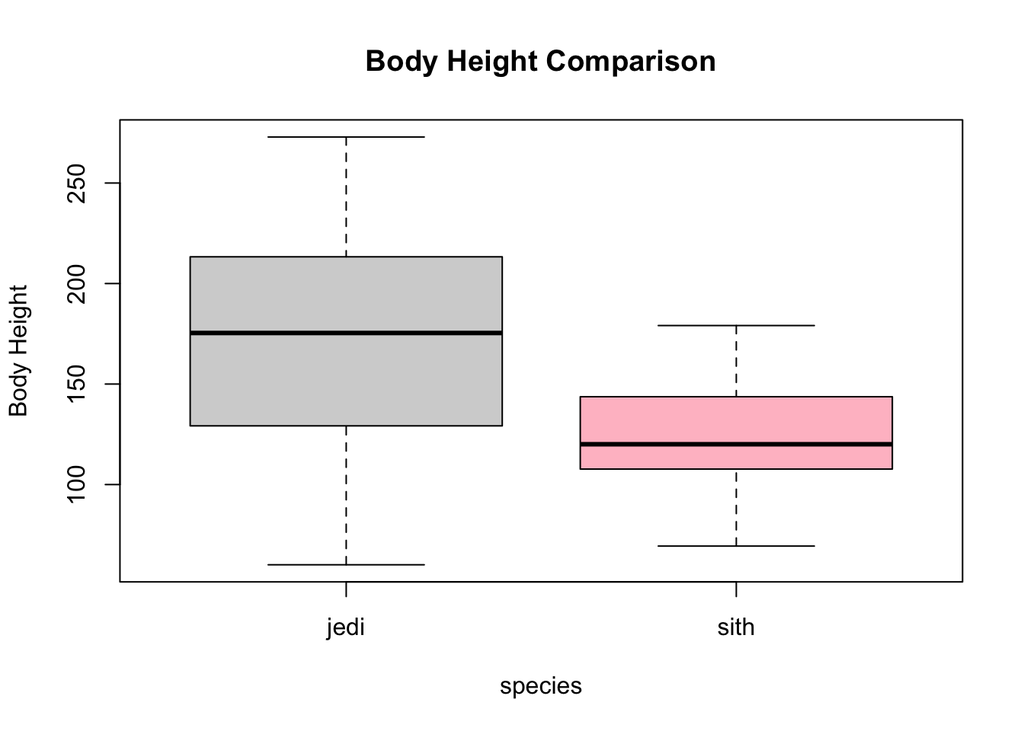

```r
jedi <- magic_guys$length[magic_guys$species == "jedi"]
sith <- magic_guys$length[magic_guys$species == "sith"]

# Basic boxplot
boxplot(length ~ species,
        data = magic_guys,
        main = "Body Height Comparison",
        ylab = "Body Height",
        col = c("lightgrey", "pink"))
```

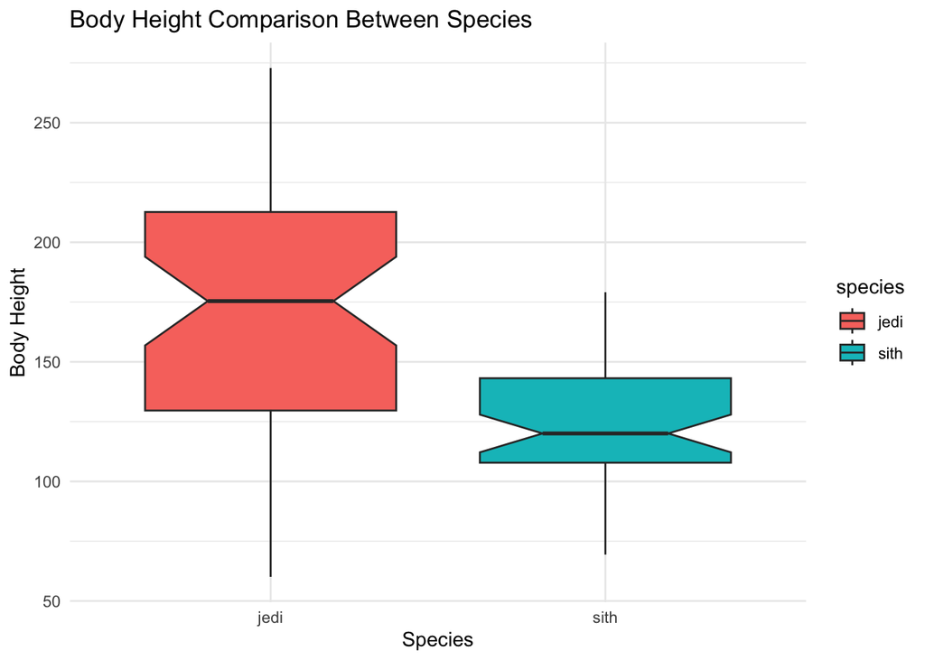

```r
# ggplot boxplot
ggplot(magic_guys, aes(x = species, y = length, fill = species)) +
  geom_boxplot(notch=TRUE) +
  labs(title = "Body Height Comparison Between Species",
       x = "Species",
       y = "Body Height") +
  theme_minimal()
```

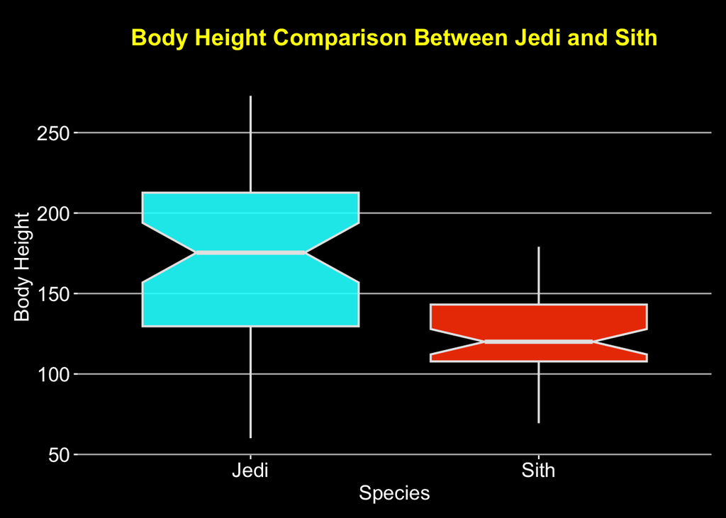

```r
## optimize ggplot
# Create the boxplot with custom Star Wars theme
ggplot(magic_guys, aes(x = species, y = length, fill = species)) +
  # Boxplot with custom color settings
  geom_boxplot(
    notch = TRUE,
    color = "grey90",  # Box outline color (medium grey)
    lwd = 0.7,        # Line width of the box outline
    alpha = 0.9      # 90% opacity for the fill colors
  ) +

  # Add title and axis labels
  labs(title = "Body Height Comparison Between Jedi and Sith",
       x = "Species",
       y = "Body Height") +

  # Custom fill colors for Jedi (neon blue) and Sith (neon red)
  scale_fill_manual(
    values = c(
      "jedi" = "#00FFFF",  # Neon blue for Jedi
      "sith" = "#FF4500"   # Neon red for Sith
    )
  ) +

  # Rename "jedi" to "Jedi" and "sith" to "Sith" directly in ggplot
  scale_x_discrete(
    labels = c("jedi" = "Jedi", "sith" = "Sith")
  ) +

  # Custom theme for Star Wars look
  theme_minimal() +
  theme(
    legend.position = "none",  # Hide legend
    plot.title = element_text(size = 16,
                              face = "bold",
                              hjust = 0.5,
                              color = "yellow",
                              margin = margin(b = 20)),  # Yellow title
    plot.background = element_rect(fill = "black"),
    panel.background = element_rect(fill = "black"),
    axis.text = element_text(color = "white", size = 14),
    axis.title = element_text(color = "white", size = 14),
    axis.ticks = element_line(color = "white"),
    panel.grid.major.x = element_blank(),
    panel.grid.minor.x = element_blank(),
    panel.grid.major.y = element_line(color = "gray"),
    panel.grid.minor.y = element_blank(),
    plot.margin = margin(t = 20, r = 10, b = 10, l = 10)
  )
```

Save output as png, pdf and svg

```r
library(svglite)

# Save in PNG format
ggsave("height_comparison.png", plot = last_plot(), width = 7, height = 5)

# Save in PDF format
ggsave("height_comparison.pdf", plot = last_plot(), width = 7, height = 5)

# Save in SVG format
ggsave("height_comparison.svg", plot = last_plot(), width = 7, height = 5)
```

Figures that are used on the web or have many colors are best saved in a png format. Pdf formats are best used for high-quality prints, vector based graphics and are scalable. Figures/ graphics that will be embedded in web pages and should be scalable are best saved in an svg format (it’s a vector based format).

Microarray dataset

```r
# Load the data
microarray_data <- read.delim("microarray_data.tab", sep = "\t", header = TRUE)

# Check the size (rows and columns)
dim(microarray_data)  # This returns the number of rows and columns
```

```
## [1]  553 1000
```

The dataset has 553 rows and 1000 columns.

Missing values per gene (with vizualisation)

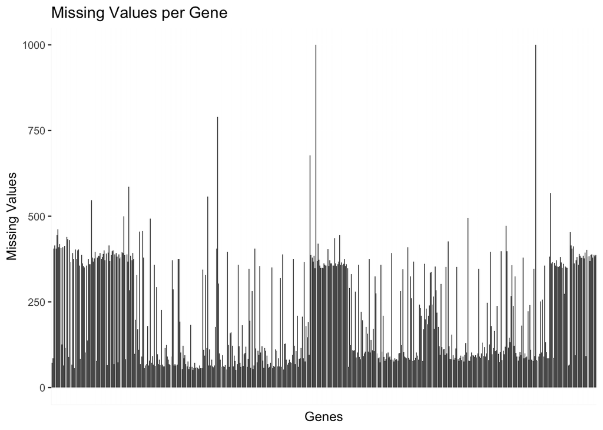

```r
# Count missing values per gene
missing_counts <- apply(microarray_data, 1, function(x) sum(is.na(x)))

# Visualize missing values
library(ggplot2)
ggplot(data.frame(gene = rownames(microarray_data),
                  missing_count = missing_counts),
       aes(x = gene, y = missing_count)) +
  geom_bar(stat = "identity") +
  theme(axis.text.x = element_blank(), axis.ticks.x = element_blank()) +
  labs(title = "Missing Values per Gene", x = "Genes", y = "Missing Values")
```

Identify genes with specific missing values

```r
# Set percentage thresholds
threshold_10 <- 0.1 * ncol(microarray_data)
threshold_20 <- 0.2 * ncol(microarray_data)
threshold_50 <- 0.5 * ncol(microarray_data)

# Filter genes with more than X% missing values
genes_10_percent <- which(missing_counts > threshold_10)
genes_20_percent <- which(missing_counts > threshold_20)
genes_50_percent <- which(missing_counts > threshold_50)

# Display the genes
genes_10_percent
```

```
##   [1]   2   5   7  13  17  18  19  21  24  25  26  27  28  29  30  31  32  33
##  [19]  34  35  36  37  38  39  40  41  42  43  44  45  46  47  48  49  50  51
##  [37]  52  53  54  55  56  57  58  59  60  61  62  63  64  65  66  67  68  69
##  [55]  70  71  72  75  76  77  78  79  80  81  82  83  84  85  86  87  88  89
##  [73]  90  91  92  93  94  95  96  97  98  99 100 101 102 103 104 105 106 107
##  [91] 108 109 110 111 112 113 115 116 118 119 120 121 122 123 124 126 127 128
## [109] 129 130 131 132 133 134 135 136 137 138 139 140 141 142 143 144 145 146
## [127] 147 148 149 150 151 152 153 154 155 157 158 159 160 161 162 163 164 165
## [145] 166 168 169 170 171 172 173 174 176 177 178 179 182 183 187 193 195 202
## [163] 203 209 214 215 216 217 219 226 237 238 240 241 243 249 250 251 260 262
## [181] 263 264 270 273 276 277 280 282 285 286 288 290 291 294 295 303 304 308
## [199] 311 312 320 322 323 327 328 331 332 333 335 336 337 338 339 340 341 342
## [217] 343 344 345 346 347 348 349 350 351 352 353 354 355 356 357 358 359 360
## [235] 361 362 363 364 365 366 367 368 369 371 372 373 374 375 376 377 379 382
## [253] 383 386 387 388 389 390 391 392 393 394 395 396 400 401 406 417 418 419
## [271] 420 424 427 428 432 435 436 437 439 440 441 442 443 444 445 446 447 448
## [289] 449 450 451 452 453 455 456 457 458 461 462 465 469 478 479 483 493 495
## [307] 498 500 502 503 504 505 506 509 511 513 514 515 516 517 518 519 520 521
## [325] 522 523 527 529 534 536 537 541 546 547 548 550 551
```

```r
genes_20_percent
```

```
##   [1]   2   7  17  18  19  21  24  25  26  27  28  29  30  31  32  33  34  35
##  [19]  36  37  38  39  40  41  42  43  44  45  46  47  48  49  50  51  52  53
##  [37]  54  55  56  57  58  59  60  61  62  63  64  65  66  67  68  69  70  71
##  [55]  72  75  76  77  78  79  80  81  82  83  84  85  86  87  88  89  90  91
##  [73]  92  93  94  95  96  97  98  99 100 101 102 103 104 105 106 107 109 110
##  [91] 112 113 115 116 118 119 120 121 122 123 124 126 127 128 129 130 132 133
## [109] 134 135 136 137 138 139 140 141 142 143 144 145 146 147 148 149 150 151
## [127] 152 153 154 155 157 158 159 160 161 162 163 164 165 166 168 169 170 171
## [145] 172 173 174 177 182 183 193 195 209 214 215 237 241 250 251 282 285 308
## [163] 323 328 335 336 337 338 339 340 341 342 343 344 345 346 347 348 349 350
## [181] 351 352 353 354 355 356 357 358 359 360 361 362 363 364 365 366 367 368
## [199] 369 371 373 377 382 395 396 401 418 424 427 428 435 436 437 441 443 444
## [217] 445 446 447 448 450 451 455 461 498 506 514 515 519 520 522 534 536 541
## [235] 546 548
```

```r
genes_50_percent
```

```
## [1]  17  57 135 241 250 335 340 541
```

```r
# Replacing missing values with the avarage expression for each gene
# Replace missing values with the mean per gene
microarray_data_imputed <- microarray_data  # Create a copy
microarray_data_imputed[] <- apply(microarray_data_imputed, 1,
                                   function(x) ifelse(is.na(x), mean(x, na.rm = TRUE), x))
```

Now `microarray_data_imputed` contains the imputed data

Visualization of CO2 dataset with the goal of gaining deeper inside

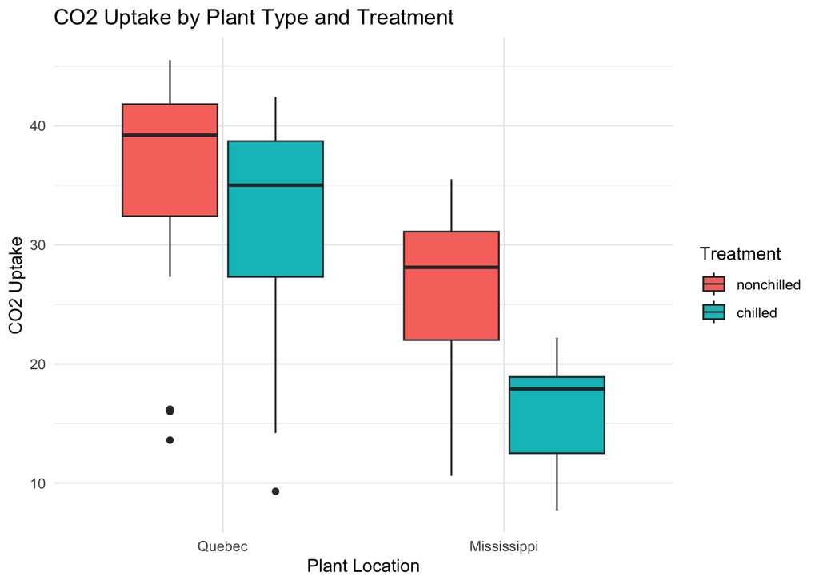

```r
# Load CO2 dataset
data("CO2")

# Plotting CO2 uptake by Plant type
ggplot(CO2, aes(x = Type, y = uptake, fill = Treatment)) +
  geom_boxplot() +
  labs(title = "CO2 Uptake by Plant Type and Treatment",
       x = "Plant Location",
       y = "CO2 Uptake") +
  theme_minimal()
```

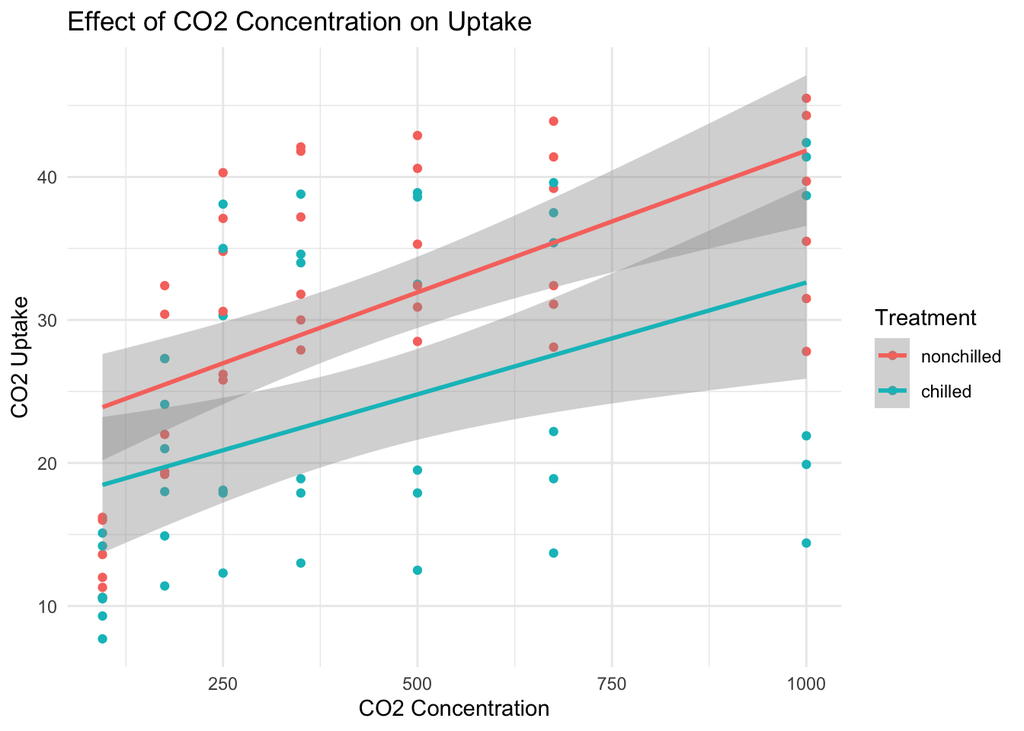

```r
# Scatter plot to see the effect of concentration on CO2 uptake
ggplot(CO2, aes(x = conc,
                y = uptake,
                color = Treatment)) +
  geom_point() +
  geom_smooth(method = "lm") +
  labs(title = "Effect of CO2 Concentration on Uptake",
       x = "CO2 Concentration",
       y = "CO2 Uptake") +
  theme_minimal()
```

```r
# Scatter plot for the four specific groups: Nonchilled/Chilled & Quebec/Mississippi
# Check the interaction levels
interaction(CO2$Type, CO2$Treatment)
```

```
##  [1] Quebec.nonchilled      Quebec.nonchilled      Quebec.nonchilled
##  [4] Quebec.nonchilled      Quebec.nonchilled      Quebec.nonchilled
##  [7] Quebec.nonchilled      Quebec.nonchilled      Quebec.nonchilled
## [10] Quebec.nonchilled      Quebec.nonchilled      Quebec.nonchilled
## [13] Quebec.nonchilled      Quebec.nonchilled      Quebec.nonchilled
## [16] Quebec.nonchilled      Quebec.nonchilled      Quebec.nonchilled
## [19] Quebec.nonchilled      Quebec.nonchilled      Quebec.nonchilled
## [22] Quebec.chilled         Quebec.chilled         Quebec.chilled
## [25] Quebec.chilled         Quebec.chilled         Quebec.chilled
## [28] Quebec.chilled         Quebec.chilled         Quebec.chilled
## [31] Quebec.chilled         Quebec.chilled         Quebec.chilled
## [34] Quebec.chilled         Quebec.chilled         Quebec.chilled
## [37] Quebec.chilled         Quebec.chilled         Quebec.chilled
## [40] Quebec.chilled         Quebec.chilled         Quebec.chilled
## [43] Mississippi.nonchilled Mississippi.nonchilled Mississippi.nonchilled
## [46] Mississippi.nonchilled Mississippi.nonchilled Mississippi.nonchilled
## [49] Mississippi.nonchilled Mississippi.nonchilled Mississippi.nonchilled
## [52] Mississippi.nonchilled Mississippi.nonchilled Mississippi.nonchilled
## [55] Mississippi.nonchilled Mississippi.nonchilled Mississippi.nonchilled
## [58] Mississippi.nonchilled Mississippi.nonchilled Mississippi.nonchilled
## [61] Mississippi.nonchilled Mississippi.nonchilled Mississippi.nonchilled
## [64] Mississippi.chilled    Mississippi.chilled    Mississippi.chilled
## [67] Mississippi.chilled    Mississippi.chilled    Mississippi.chilled
## [70] Mississippi.chilled    Mississippi.chilled    Mississippi.chilled
## [73] Mississippi.chilled    Mississippi.chilled    Mississippi.chilled
## [76] Mississippi.chilled    Mississippi.chilled    Mississippi.chilled
## [79] Mississippi.chilled    Mississippi.chilled    Mississippi.chilled
## [82] Mississippi.chilled    Mississippi.chilled    Mississippi.chilled
## 4 Levels: Quebec.nonchilled Mississippi.nonchilled ... Mississippi.chilled
```

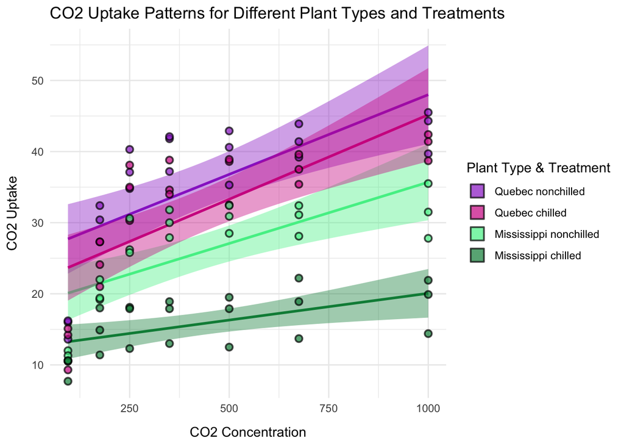

```r
# Create the updated scatter plot
ggplot(CO2, aes(x = conc, y = uptake, fill = interaction(Type, Treatment),
                color = interaction(Type, Treatment))) +

  # Smoothed regression line without standard error, matching the colors of points
  geom_smooth(method = "lm", se = TRUE, size = 1, show.legend = FALSE) +

  # Scatter plot with black outline layered above the regression lines and
  # standard error margin
  geom_point(shape = 21, size = 2, alpha = 0.7, stroke = 1, color = "black") +

  labs(
    title = "CO2 Uptake Patterns for Different Plant Types and Treatments",
    x = "CO2 Concentration",
    y = "CO2 Uptake",
    fill = "Plant Type & Treatment"
  ) +
  theme_minimal() +

  # Custom colors for each category, with specified order
  scale_fill_manual(
    values = c(
      "Quebec.nonchilled" = "darkorchid",
      "Quebec.chilled" = "violetred",
      "Mississippi.nonchilled" = "seagreen2",
      "Mississippi.chilled" = "springgreen4"
    ),
    labels = c(
      "Quebec.nonchilled" = "Quebec nonchilled",
      "Quebec.chilled" = "Quebec chilled",
      "Mississippi.nonchilled" = "Mississippi nonchilled",
      "Mississippi.chilled" = "Mississippi chilled"
    ),
    limits = c("Quebec.nonchilled", # Ensure the legend order
               "Quebec.chilled",
               "Mississippi.nonchilled",
               "Mississippi.chilled")
  ) +

  # Matching color scale for regression lines, with the same order
  scale_color_manual(
    values = c(
      "Quebec.nonchilled" = "darkorchid",
      "Quebec.chilled" = "violetred",
      "Mississippi.nonchilled" = "seagreen2",
      "Mississippi.chilled" = "springgreen4"
    ),
    limits = c("Quebec.nonchilled",  # Ensure the legend order
               "Quebec.chilled",
               "Mississippi.nonchilled",
               "Mississippi.chilled")
  ) +

  # Remove the color legend for the regression line and set up square symbols for
  # the points
  guides(
    fill = guide_legend(
      override.aes = list(shape = 22, size = 5, color = "black", stroke = 1),
      order = 1  # Ensures that the legend is ordered correctly
    ),
    color = "none"  # Hide the separate color legend for smoothed lines
  ) +

  # Adjust the distance between the axis titles and ticks
  theme(
    axis.title.x = element_text(margin = margin(t = 10)),
    axis.title.y = element_text(margin = margin(r = 10))
  )
```

The CO2 uptake of the plants in Quebec is higher then in Mississippi. In both locations plants that are not treated (nonchilled) have a higher CO2 uptake. With increasing CO2 concentration the CO2 uptake increases as well.

Task 7

```r
# Load the tidyverse and tidybiology packages
library(tidyverse)
library(tidybiology)

# Load the chromosome data
data("chromosome")

# Extract summary statistics
summary_stats <- chromosome %>%
  summarise(
    mean_variations = mean(variations, na.rm = TRUE),
    median_variations = median(variations, na.rm = TRUE),
    max_variations = max(variations, na.rm = TRUE),

    mean_protein_coding_genes = mean(protein_codinggenes, na.rm = TRUE),
    median_protein_coding_genes = median(protein_codinggenes, na.rm = TRUE),
    max_protein_coding_genes = max(protein_codinggenes, na.rm = TRUE),

    mean_mi_rna = mean(mi_rna, na.rm = TRUE),
    median_mi_rna = median(mi_rna, na.rm = TRUE),
    max_mi_rna = max(mi_rna, na.rm = TRUE)
  )

# Display the summary data
summary_stats
```

| mean_variations | median_variations | max_variations | mean_protein_coding_genes | median_protein_coding_genes | max_protein_coding_genes | mean_mi_rna | median_mi_rna | max_mi_rna |
| --- | --- | --- | --- | --- | --- | --- | --- | --- |
| 6484572 | 6172346 | 12945965 | 849.9583 | 836 | 2058 | 73.16667 | 75 | 134 |

Mean Variations = 6484572 Median Variations = 6172346 Max Variations = 12945965

Mean Protein-coding genes = 850 Median Protein-coding genes = 836 Max Protein-coding genes = 2058

Mean miRNA = 73.2 Median miRNA = 75 Max miRNA = 134

Distribution of chromosome size

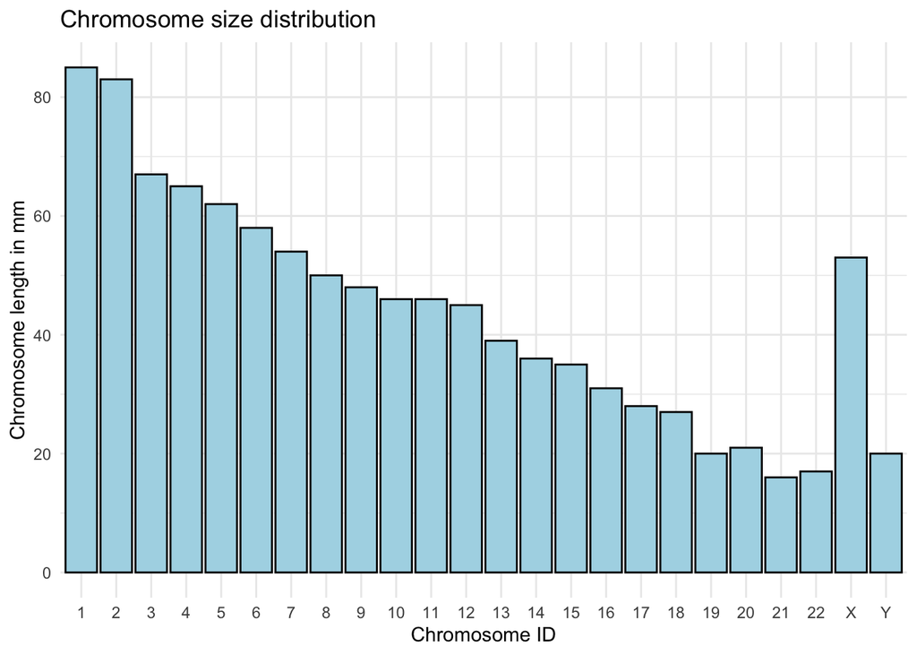

```r
# Bar plot
ggplot(chromosome, aes(x = id, y = length_mm)) +
  geom_bar(stat = "identity", fill = "lightblue", color = "black") +
  labs(title = "Chromosome size distribution",
       x = "Chromosome ID",
       y = "Chromosome length in mm") +
  theme_minimal()
```

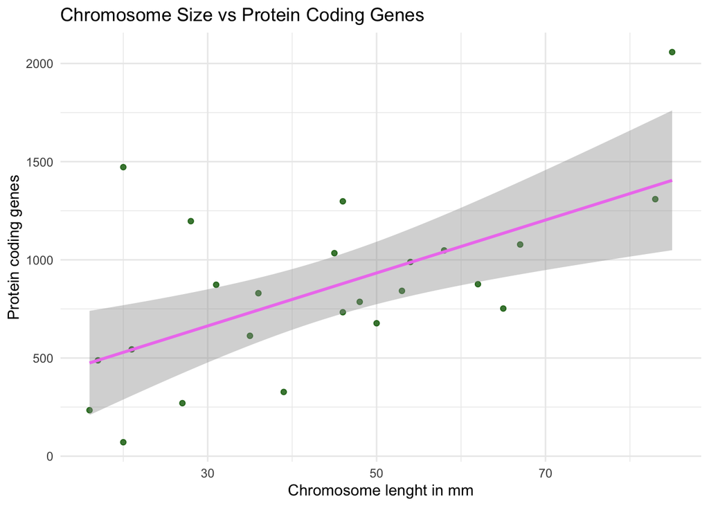

```r
# Correlation between protein coding genes and miRNAs with chromosome length
# Chromosome length and protein coding genes
ggplot(chromosome, aes(x = length_mm, y = protein_codinggenes)) +
  geom_point(color = "darkgreen", alpha = 0.8) +
  geom_smooth(method = "lm", color = "violet", se = TRUE) +
  labs(title = "Chromosome Size vs Protein Coding Genes",
       x = "Chromosome lenght in mm",
       y = "Protein coding genes") +
  theme_minimal()
```

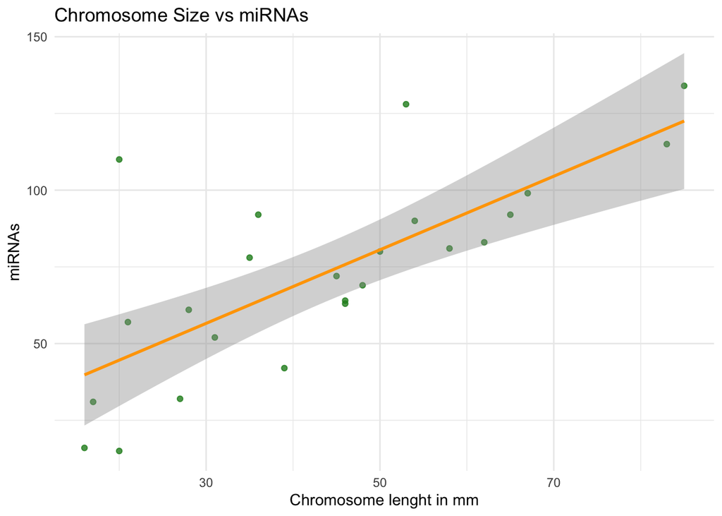

```r
# Chromosome length and miRNA
ggplot(chromosome, aes(x = length_mm, y = mi_rna)) +
  geom_point(color = "forestgreen", alpha = 0.8) +
  geom_smooth(method = "lm", color = "orange", se = TRUE) +
  labs(title = "Chromosome Size vs miRNAs",
       x = "Chromosome lenght in mm",
       y = "miRNAs") +
  theme_minimal()
```

Summary statistics for protein dataset

```r
# Load protein data
data("proteins")

# Summary statistics for length and mass
summary_stats_proteins <- proteins %>%
  summarize(
    mean_length = mean(length, na.rm = TRUE),
    median_length = median(length, na.rm = TRUE),
    max_length = max(length, na.rm = TRUE),

    mean_mass = mean(mass, na.rm = TRUE),
    median_mass = median(mass, na.rm = TRUE),
    max_mass = max(mass, na.rm = TRUE)
  )

# Display the summary statistics
summary_stats_proteins
```

| mean_length | median_length | max_length | mean_mass | median_mass | max_mass |
| --- | --- | --- | --- | --- | --- |
| 557.1603 | 414 | 34350 | 62061.38 | 46140.5 | 3816030 |

mean length / median length / max length 557 414 34350  
mean mass / median mass / max mass 62061 46140 3816030

Plot to visualize length and mass relationship of protein dataset

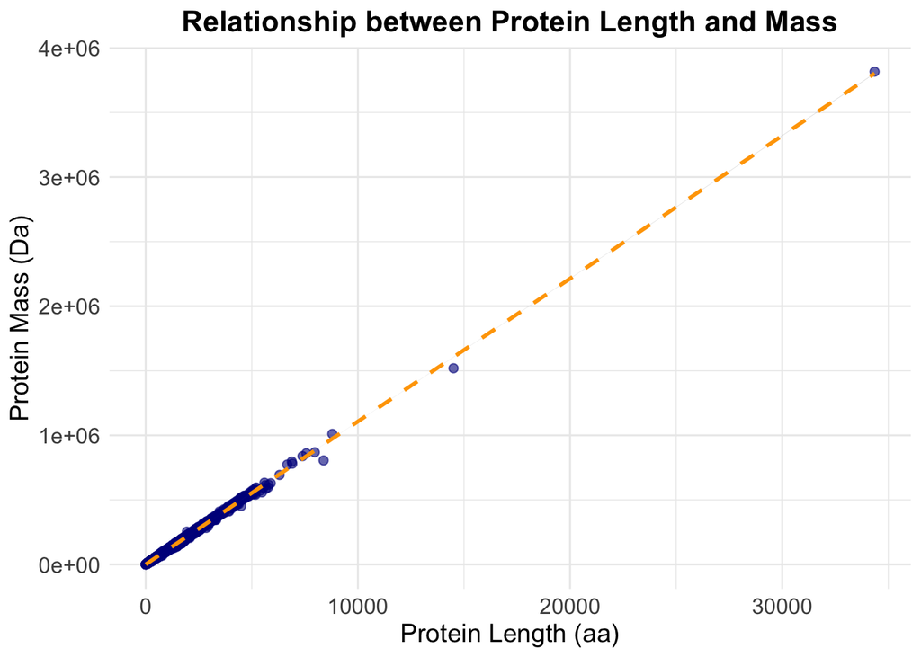

```r
# Scatter plot of length vs. mass with enhanced visualization
ggplot(proteins, aes(x = length, y = mass)) +
  geom_point(color = "darkblue", alpha = 0.6, size = 2) +
  geom_smooth(method = "lm", color = "orange", se = TRUE, linetype = "dashed") +
  labs(title = "Relationship between Protein Length and Mass",
       x = "Protein Length (aa)",
       y = "Protein Mass (Da)") +
  theme_minimal() +
  theme(plot.title = element_text(hjust = 0.5, size = 16, face = "bold"),
        axis.title = element_text(size = 14),
        axis.text = element_text(size = 12))
```